# Report

Zhe Yu, Rong Li

2020/11/11

# Introduction

In this assignment, we use additional county level data from FEMA to produce maps with more features. The purpose of this assignment is to show our ability of using R to produce documents, presentations, and shiny apps.

# Data Collection

## Data Description

The Public Assistance Funded Projects Details dataset contains obligated (financial obligation to grantee) Public Assistance projects, lists public assistance recipients designated as applicants in the data, and a list of every funded, individual project, called project worksheets. Open projects still under pre-obligation processing are not represented. This is raw, unedited data from FEMA’s National Emergency Management Information System (NEMIS).

## Load Data

We download raw data [PublicAssistanceFundedProjectsDetails.csv](https://www.fema.gov/openfema-data-page/public-assistance-funded-projects-details-v1) from the website of FEMA and load into R.

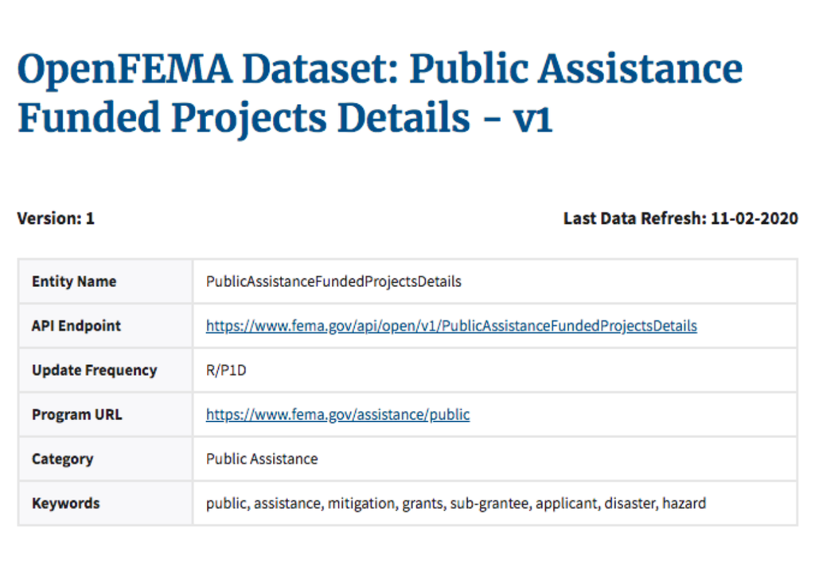

There are 79192 rows and 22 columns.

## Obtain Hurricane Data from 2009 to 2018

After selecting hurricane data from 2009 to 2018 and deleting the missing data, we get 79171 observations.  
Here are the first several rows and columns of the data:

```
##   disasterNumber     declarationDate incidentType pwNumber applicationTitle
## 1           1866 2009-12-22 05:00:00    Hurricane        1      DIW-097-02F
## 2           1866 2009-12-22 05:00:00    Hurricane        2      DIW-097-01F
## 3           1866 2009-12-22 05:00:00    Hurricane        3      DIW-097-03F
## 4           1866 2009-12-22 05:00:00    Hurricane        4      DIW-097-04F
## 5           1866 2009-12-22 05:00:00    Hurricane        5      DIW-097-01B
```

# EDA

In this part, we focus on column `projectAmount` – the estimated total cost of the Public Assistance grant project in dollars, without administrative costs. This amount is based on the damage survey.  
We calculate the total project amount for each state, each year, different project sizes and different damage categories and display it using barplot.

## Total Project Amount for Each State

### Table

We calculate the total project amount for each state. Only 10 states with the largest number of project amount are shown. The whole table is available in Appendix.

| state | sum |
| --- | --- |
| Puerto Rico | 20936310576 |
| New York | 16927478331 |
| Florida | 4463746795 |
| Texas | 2540619000 |
| Virgin Islands of the U.S. | 2523344651 |
| New Jersey | 2390999589 |
| North Carolina | 1325808430 |
| South Carolina | 486954380 |
| Georgia | 453679553 |
| Louisiana | 453214650 |

### Barplot

Because the top 10 projectAmounts are too large, they are ploted in one graph. And the others are in another plot.

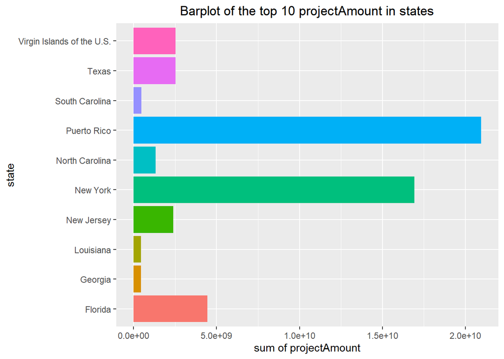

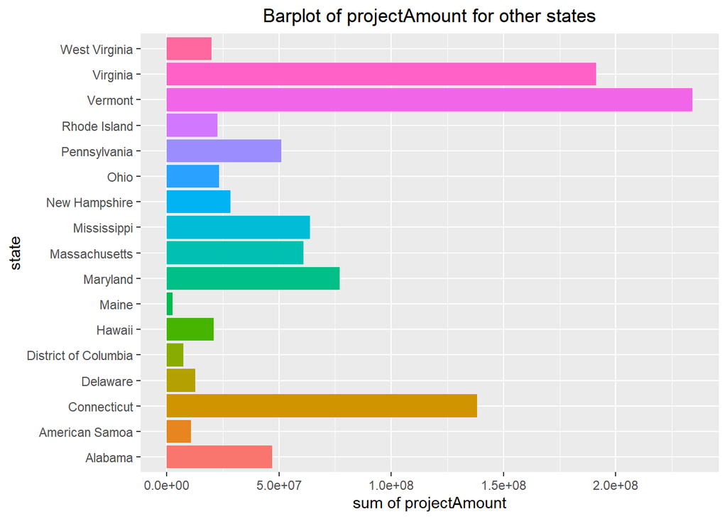

## Total Project Amount for Each Year

### Table

We calculate the total project amount for each year.

| beginyear | sum |
| --- | --- |
| 2017 | 28502284412 |
| 2012 | 19141051210 |
| 2018 | 2772562070 |
| 2011 | 1619491113 |
| 2016 | 1401518239 |
| 2013 | 40234873 |
| 2010 | 31720861 |
| 2009 | 5547017 |

### Barplot

Because the top 2 projectAmounts are too large, they are ploted in one graph. And the No.3-No.5 projectAmounts are in another plot for the same reason. The third plot contains the rest of projectAmounts.

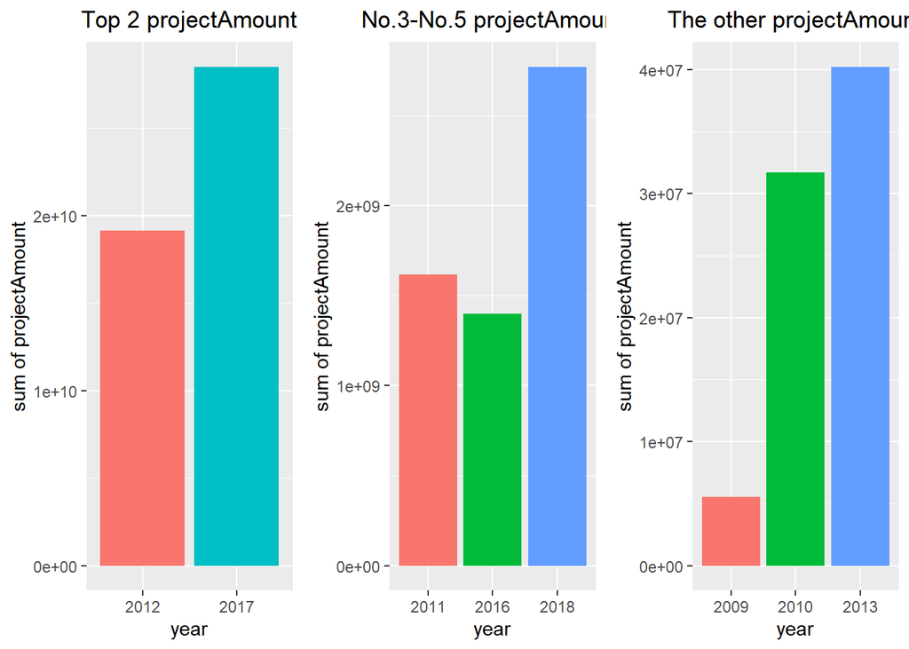

## Total Project Amount for Different Project Size

### Table

We calculate the total project amount for different project sizes.

| projectSize | sum |
| --- | --- |
| Large | 52242109567 |
| Small | 1272300227 |

| projectSize | count |
| --- | --- |
| Large | 17428 |
| Small | 61743 |

### Barplot

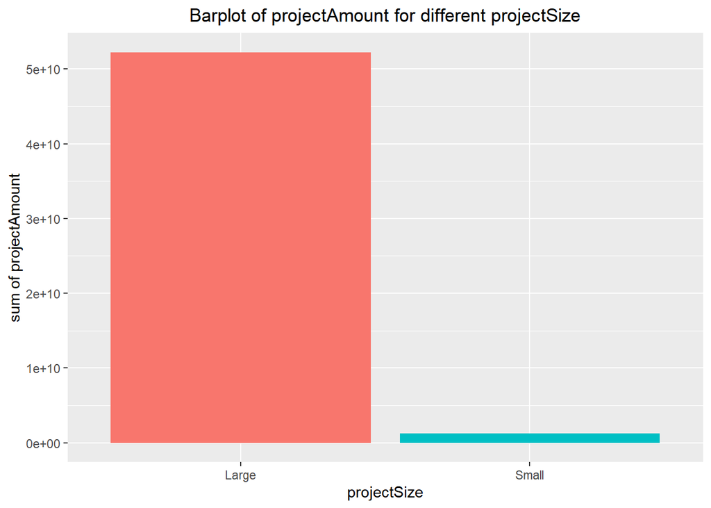

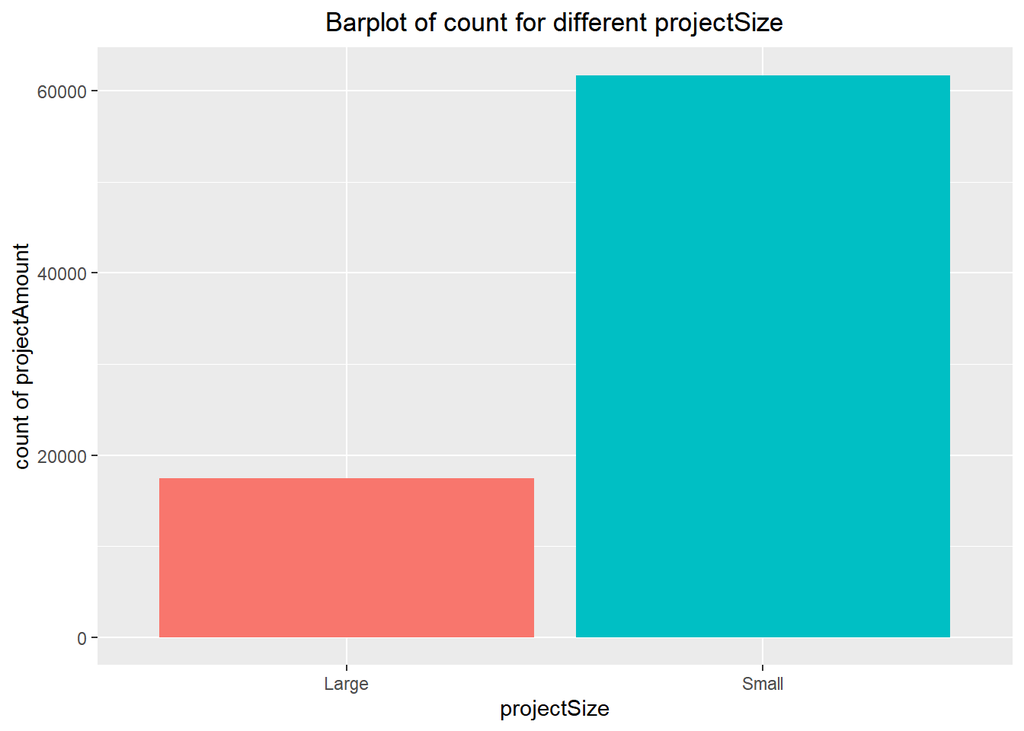

## Total Project Amount for Different Damage Categories

### Table

We calculate the total project amount for different damage categories.

| dcc | sum |
| --- | --- |
| F | 16291752391 |
| B | 11784476587 |
| E | 11774539483 |
| A | 5738378249 |
| G | 3309757035 |
| C | 2771202628 |
| Z | 1537575545 |
| D | 306727876 |

### Barplot

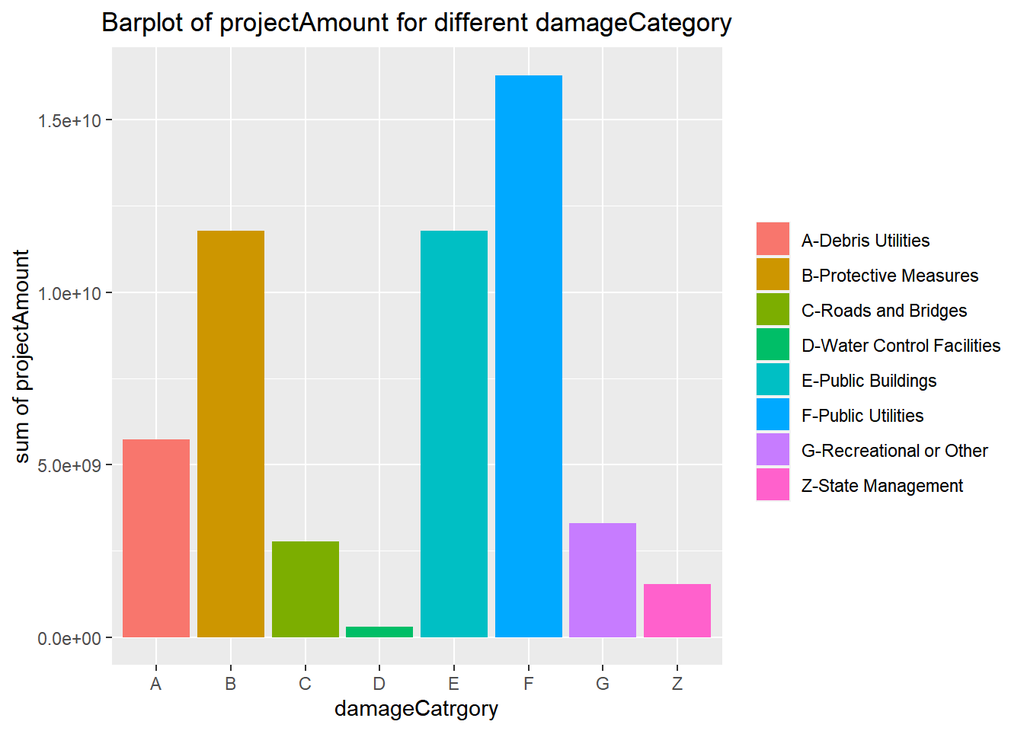

# Mapping with ‘leaflet’

In this part, we draw maps to show the estimated total cost in states and counties.

## Combine Fips Code with Maps Data

```r
#combine the fips with maps data
##county
data(county.fips)
mapcounty=st_as_sf(map('county',plot=F,fill=T))
colnames(county.fips)[2]=colnames(mapcounty)[1]
mapcounty=left_join(mapcounty,county.fips,'ID')

##state
data(state.fips)
mapstate=st_as_sf(map('state',plot = F,fill = T))
colnames(state.fips)[6]=colnames(mapstate)[1]
mapstate=left_join(mapstate,state.fips,'ID')
mapstate[20,2:6]<-c(25,22,1,1,"MA")
mapstate[21,2:6]<-c(26,23,2,3,"MI")
mapstate[31,2:6]<-c(36,33,1,2,"NY")
mapstate[32,2:6]<-c(37,34,3,5,"NC")
mapstate[45,2:6]<-c(51,49,3,5,"VA")
mapstate[46,2:6]<-c(53,50,4,9,"WA")
colnames(mapstate)[2] <- "stateNumberCode"
mapstate$stateNumberCode<- as.numeric(mapstate$stateNumberCode)

#combine data
#by state
hurricane_group<- group_by(PAFPD_0918, stateNumberCode)
h_GroupByfips<- summarise(hurricane_group,sumcost = sum(projectAmount),.groups='drop')
h_GroupByfips<- h_GroupByfips[order(h_GroupByfips$sumcost,decreasing=F),]
hcount_s <- right_join(mapstate,h_GroupByfips,"stateNumberCode")

#by county
hurricane_group <- filter(PAFPD_0918,countyCode!=0)
hurricane_group<- group_by(hurricane_group, fips)
h_GroupByfips<- summarise(hurricane_group,sumcost = sum(projectAmount),.groups='drop')
h_GroupByfips<- h_GroupByfips[order(h_GroupByfips$sumcost,decreasing=F),]
hcount_c <- right_join(mapcounty,h_GroupByfips,"fips")
hcount_c <- filter(hcount_c,is.na(ID)==F)
hcount_c2 <- filter(hcount_c,sumcost<200000000)
hcount_c3 <- filter(hcount_c,sumcost>200000000)
```

## Maps of States

We draw the total cost of every state in map.

[interactive chart not shown]

As shown in the picture, hurricanes mainly influence the east coast. New York has the largest estimated total cost in 2009-2018.

## Maps of Counties

If we put the top 10 counties with the largest estimated total cost in the same graph with other counties, the differences among counties will be hard to find.  
So we draw the top 10 counties alone and it appears that they are still hard to find in map because of their tiny area.  
As a result, we simply list them as follows:

|  | county | funding |
| --- | --- | --- |
| 7 | new york,new york | 9800666891 |
| 6 | new york,nassau | 1812897932 |
| 8 | new york,queens | 1181782058 |
| 10 | texas,harris | 815788676 |
| 1 | florida,bay | 696292642 |
| 3 | florida,miami-dade | 382560652 |
| 4 | new jersey,monmouth | 317317875 |
| 5 | new jersey,ocean | 277788906 |
| 9 | new york,suffolk | 248392959 |
| 2 | florida,broward | 203482941 |

And the rest counties are drawn in this map:

[interactive chart not shown]

# Shiny

In shiny we not only display the ‘projectAmount’, but also show the number of hurricanes from 2009 to 2018.  
- You can choose from the sidebar to see the mapping or graphs.  
- Mapping are displayed in two scale:county level and state level. Buttons are at the topleft of mapping box.  
- In Control box you can choose which period and which state to display.  
- Some graphs also provide slide bar to choose period or certain year.

[Click here go to shiny app](https://yuzhe.shinyapps.io/MA615-midtermmap/)

# Appendix

## Total Project Amount for Each State

```
##                         state         sum
## 1                 Puerto Rico 20936310576
## 2                    New York 16927478331
## 3                     Florida  4463746795
## 4                       Texas  2540619000
## 5  Virgin Islands of the U.S.  2523344651
## 6                  New Jersey  2390999589
## 7              North Carolina  1325808430
## 8              South Carolina   486954380
## 9                     Georgia   453679553
## 10                  Louisiana   453214650
## 11                    Vermont   234192622
## 12                   Virginia   191292785
## 13                Connecticut   138181734
## 14                   Maryland    77073165
## 15                Mississippi    63891963
## 16              Massachusetts    60956986
## 17               Pennsylvania    51092293
## 18                    Alabama    46862086
## 19              New Hampshire    28459543
## 20                       Ohio    23355813
## 21               Rhode Island    22589632
## 22                     Hawaii    20814535
## 23              West Virginia    19854405
## 24                   Delaware    12779360
## 25             American Samoa    10747350
## 26       District of Columbia     7448842
## 27                      Maine     2660726
```